# data605_hw12_WZHOU

Wei Zhou

11/16/2019

### Loading Data

```r
who <- read.csv('who.csv')
head(who)
```

```
##               Country LifeExp InfantSurvival Under5Survival  TBFree
## 1         Afghanistan      42          0.835          0.743 0.99769
## 2             Albania      71          0.985          0.983 0.99974
## 3             Algeria      71          0.967          0.962 0.99944
## 4             Andorra      82          0.997          0.996 0.99983
## 5              Angola      41          0.846          0.740 0.99656
## 6 Antigua and Barbuda      73          0.990          0.989 0.99991
##        PropMD      PropRN PersExp GovtExp TotExp
## 1 0.000228841 0.000572294      20      92    112
## 2 0.001143127 0.004614439     169    3128   3297
## 3 0.001060478 0.002091362     108    5184   5292
## 4 0.003297297 0.003500000    2589  169725 172314
## 5 0.000070400 0.001146162      36    1620   1656
## 6 0.000142857 0.002773810     503   12543  13046
```

### Exporling Data

```r
summary(who)
```

```
##                 Country       LifeExp      InfantSurvival
##  Afghanistan        :  1   Min.   :40.00   Min.   :0.8350
##  Albania            :  1   1st Qu.:61.25   1st Qu.:0.9433
##  Algeria            :  1   Median :70.00   Median :0.9785
##  Andorra            :  1   Mean   :67.38   Mean   :0.9624
##  Angola             :  1   3rd Qu.:75.00   3rd Qu.:0.9910
##  Antigua and Barbuda:  1   Max.   :83.00   Max.   :0.9980
##  (Other)            :184
##  Under5Survival       TBFree           PropMD              PropRN
##  Min.   :0.7310   Min.   :0.9870   Min.   :0.0000196   Min.   :0.0000883
##  1st Qu.:0.9253   1st Qu.:0.9969   1st Qu.:0.0002444   1st Qu.:0.0008455
##  Median :0.9745   Median :0.9992   Median :0.0010474   Median :0.0027584
##  Mean   :0.9459   Mean   :0.9980   Mean   :0.0017954   Mean   :0.0041336
##  3rd Qu.:0.9900   3rd Qu.:0.9998   3rd Qu.:0.0024584   3rd Qu.:0.0057164
##  Max.   :0.9970   Max.   :1.0000   Max.   :0.0351290   Max.   :0.0708387
##
##     PersExp           GovtExp             TotExp
##  Min.   :   3.00   Min.   :    10.0   Min.   :    13
##  1st Qu.:  36.25   1st Qu.:   559.5   1st Qu.:   584
##  Median : 199.50   Median :  5385.0   Median :  5541
##  Mean   : 742.00   Mean   : 40953.5   Mean   : 41696
##  3rd Qu.: 515.25   3rd Qu.: 25680.2   3rd Qu.: 26331
##  Max.   :6350.00   Max.   :476420.0   Max.   :482750
##
```

### Q1 Provide a scatterplot of LifeExp~TotExp, and run simple linear regression. Do not transform the variables. Provide and interpret the F statistics, R^2, standard error,and p-values only. Discuss whether the assumptions of simple linear regression met.

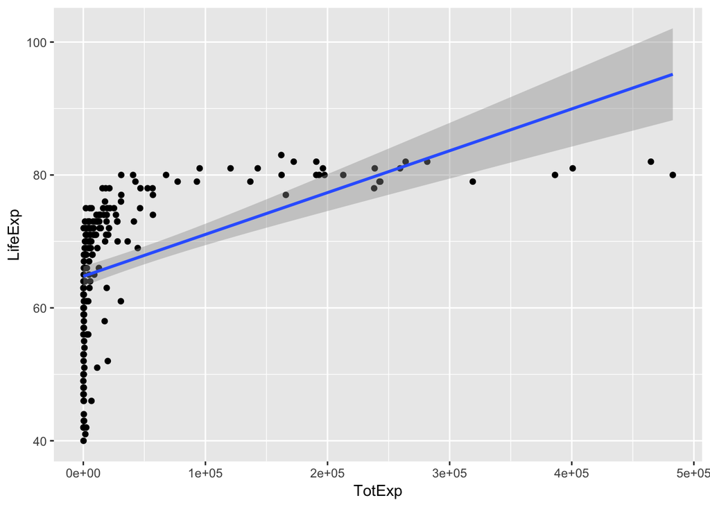

```r
library(ggplot2)
lm <- lm(LifeExp ~ TotExp, data=who)
ggplot(who, aes(x=TotExp, y=LifeExp)) + geom_point() +geom_smooth(method='lm')
```

```r
cor(who$TotExp,who$LifeExp)
```

```
## [1] 0.5076339
```

```r
summary(lm)
```

```
##
## Call:
## lm(formula = LifeExp ~ TotExp, data = who)
##
## Residuals:
##     Min      1Q  Median      3Q     Max
## -24.764  -4.778   3.154   7.116  13.292
##
## Coefficients:
##              Estimate Std. Error t value Pr(>|t|)
## (Intercept) 6.475e+01  7.535e-01  85.933  < 2e-16 ***
## TotExp      6.297e-05  7.795e-06   8.079 7.71e-14 ***
## ---
## Signif. codes:  0 '***' 0.001 '**' 0.01 '*' 0.05 '.' 0.1 ' ' 1
##
## Residual standard error: 9.371 on 188 degrees of freedom
## Multiple R-squared:  0.2577, Adjusted R-squared:  0.2537
## F-statistic: 65.26 on 1 and 188 DF,  p-value: 7.714e-14
```

The P-value for F-test is approximately 0, which is less than 0.05. We reject the null hypothesis,and accept that it is statistically significant. However the Adjusted R-squared is only 0.2537 ,which means it can only explain 25% of variability. the Standard error 9.371 is too high.

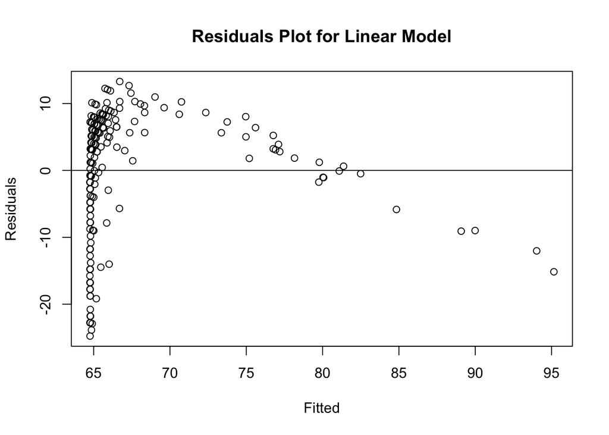

```r
plot(lm$fitted.values, lm$residuals,
     xlab="Fitted", ylab="Residuals",
     main="Residuals Plot for Linear Model")
abline(h=0)
```

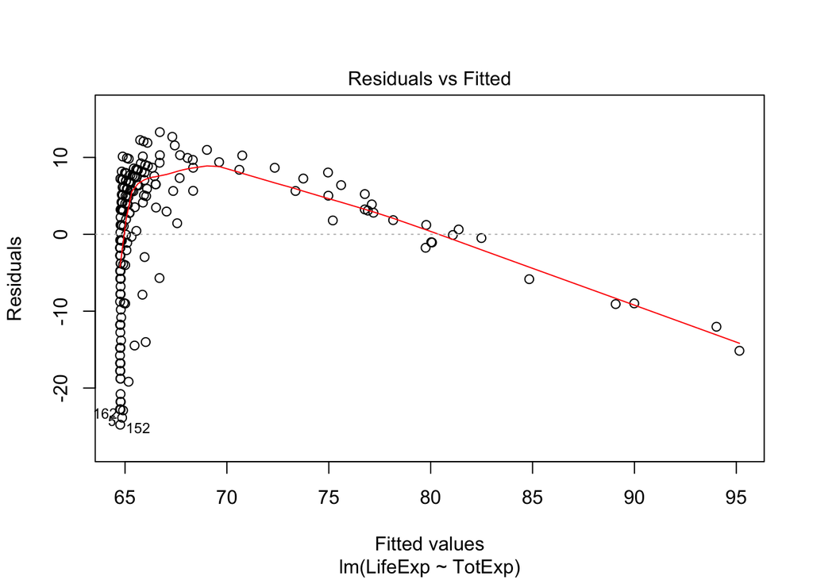

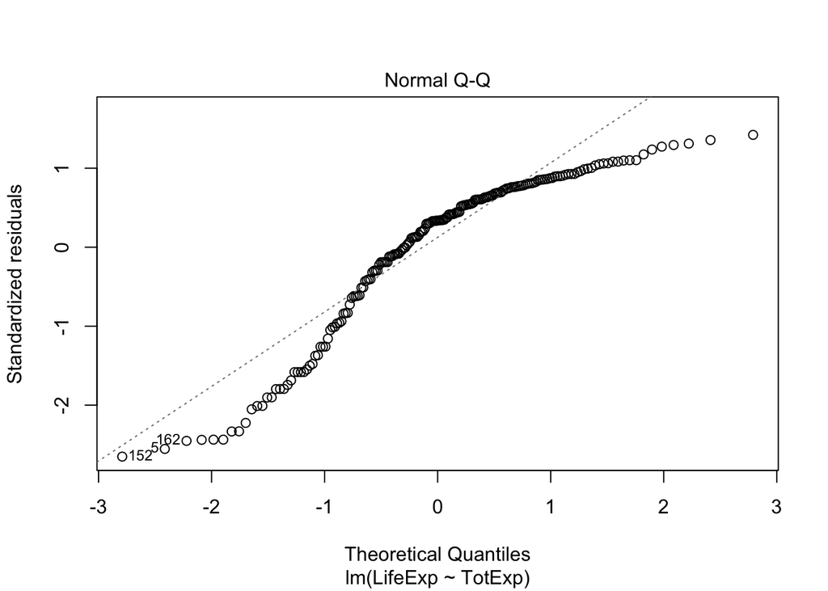

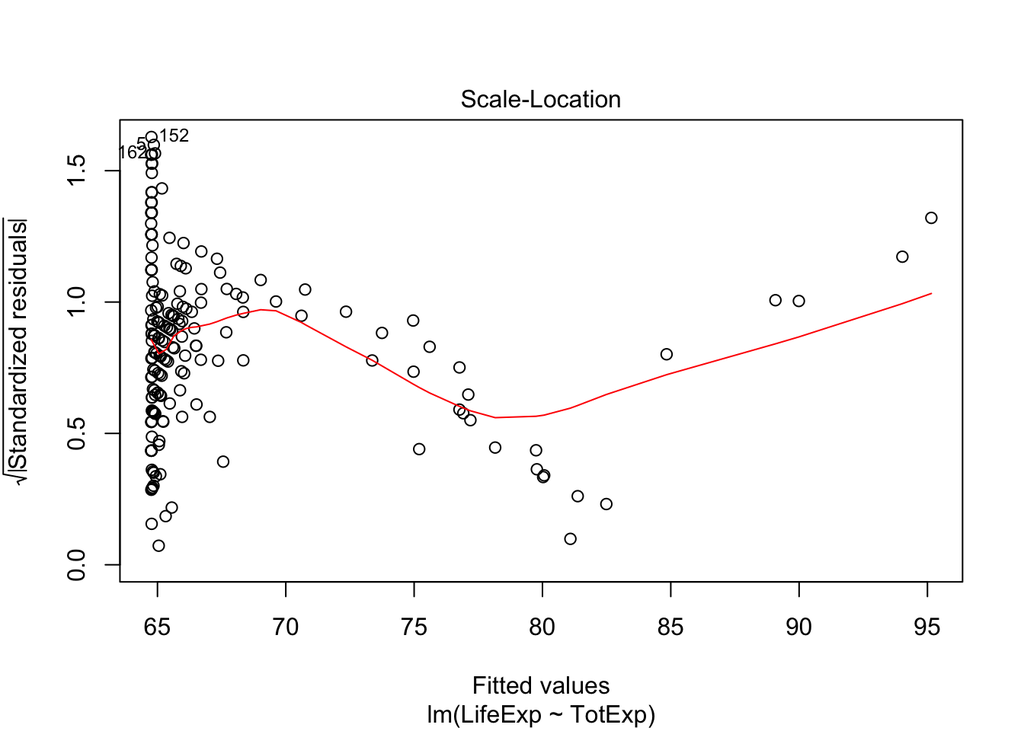

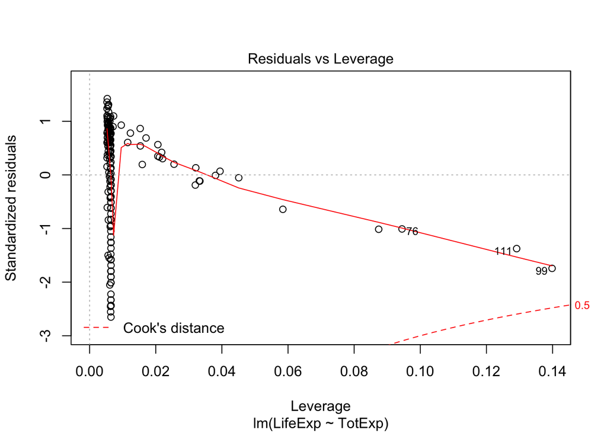

```r
plot(lm)
```

According to the diagnostic plot. we found that the constant variance condition fails and both QQ plot and residual vs.fitted value tell us that the model is not normally distributed.

### Question 2 Raise life expectancy to the 4.6 power (i.e., LifeExp^4.6). Raise total expenditures to the 0.06 power (nearly a log transform, TotExp^.06). Plot LifeExp^4.6 as a function of TotExp^.06, and r re-run the simple regression model using the transformed variables. Provide and interpret the F statistics, R^2, standard error, and p-values. Which model is “better?”

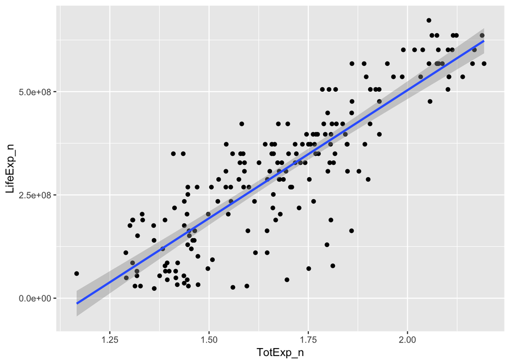

```r
LifeExp_n <- who$LifeExp^4.6
TotExp_n <- who$TotExp^0.06

# Linear regression model build
lm_n <- lm(LifeExp_n ~ TotExp_n)
ggplot(who, aes(x=TotExp_n, y=LifeExp_n)) + geom_point() +geom_smooth(method='lm')
```

```r
cor(LifeExp_n,TotExp_n)
```

```
## [1] 0.8542642
```

```r
summary(lm_n)
```

```
##
## Call:
## lm(formula = LifeExp_n ~ TotExp_n)
##
## Residuals:
##        Min         1Q     Median         3Q        Max
## -308616089  -53978977   13697187   59139231  211951764
##
## Coefficients:
##               Estimate Std. Error t value Pr(>|t|)
## (Intercept) -736527910   46817945  -15.73   <2e-16 ***
## TotExp_n     620060216   27518940   22.53   <2e-16 ***
## ---
## Signif. codes:  0 '***' 0.001 '**' 0.01 '*' 0.05 '.' 0.1 ' ' 1
##
## Residual standard error: 90490000 on 188 degrees of freedom
## Multiple R-squared:  0.7298, Adjusted R-squared:  0.7283
## F-statistic: 507.7 on 1 and 188 DF,  p-value: < 2.2e-16
```

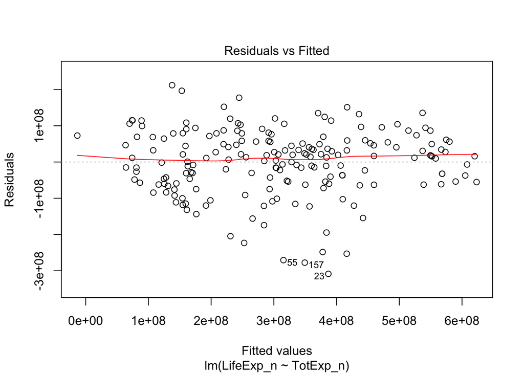

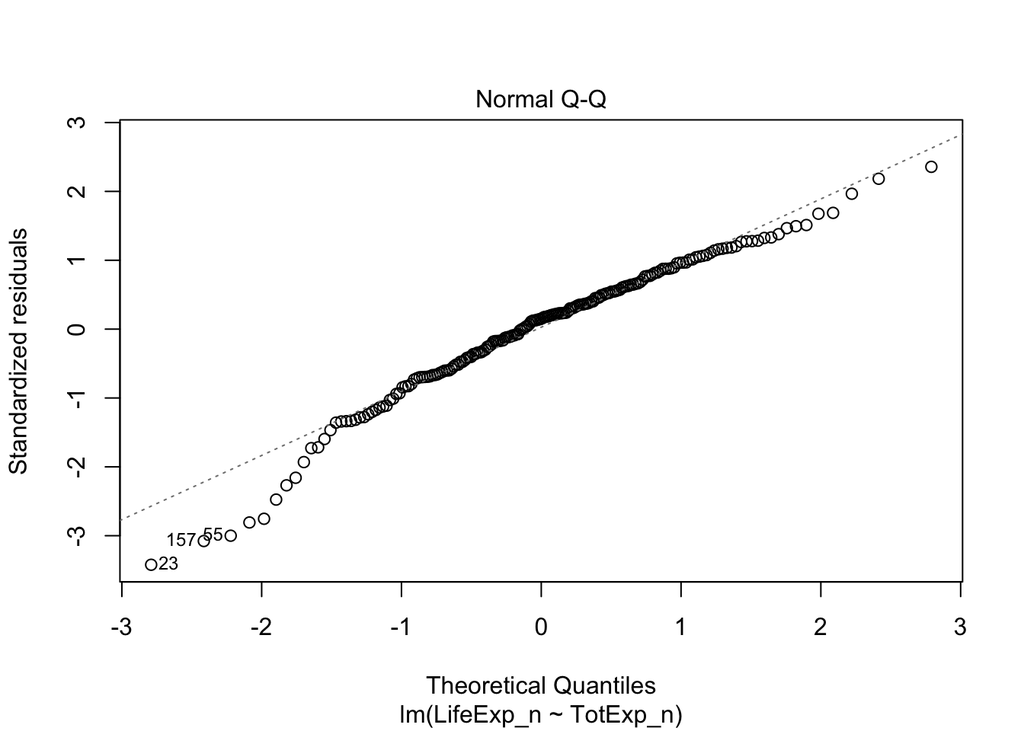

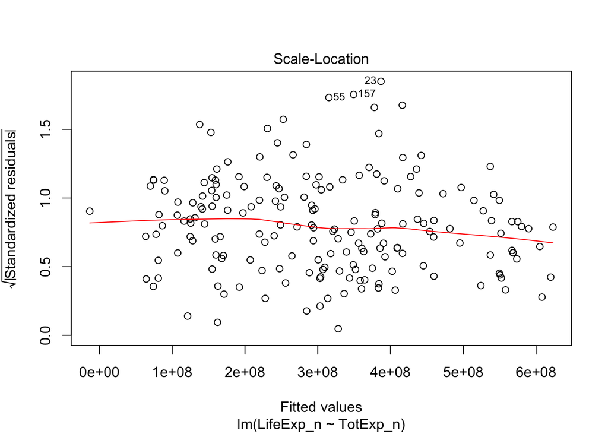

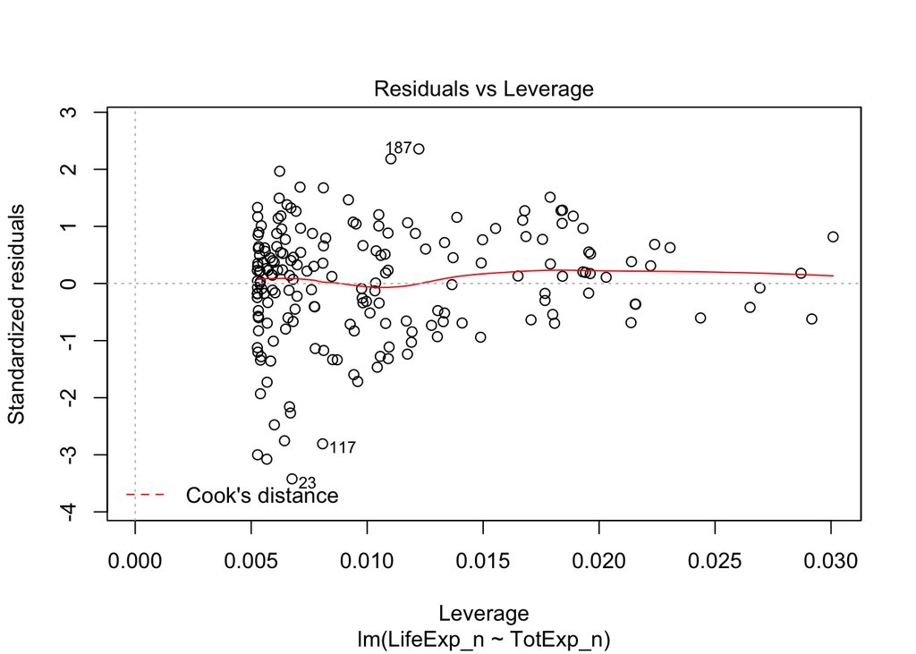

```r
plot(lm_n)
```

F−Statistic is 507.7 and the Standard Error is 90490000. The p−value is nearly 0. The correlation is 0.8543 which is much better than the previous case and R2 is 0.7298. There is a strong relationship between transformed variables TotExp and LifeExp. Therefore, we can say this transformed model is better than the previous model.

### Question 3: Using the results from 3, forecast life expectancy when TotExp^.06 =1.5. Then forecast life expectancy when TotExp^.06=2.5:

```r
x = 1.5
le = (x * lm_n$coefficients[2] + lm_n$coefficients[1])^(1/4.6)
le
```

```
## TotExp_n
## 63.31153
```

```r
x = 2.5
le = (x * lm_n$coefficients[2] + lm_n$coefficients[1])^(1/4.6)
le
```

```
## TotExp_n
## 86.50645
```

### Question 4: Build the following multiple regression model and interpret the F Statistics, R^2, standard error, and p-values. How good is the model?: LifeExp = b0+b1 x PropMd + b2 x TotExp +b3 x PropMD x TotExp

```r
lm_4 =lm(LifeExp ~ PropMD + TotExp + PropMD*TotExp, data = who)
summary(lm_4)
```

```
##
## Call:
## lm(formula = LifeExp ~ PropMD + TotExp + PropMD * TotExp, data = who)
##
## Residuals:
##     Min      1Q  Median      3Q     Max
## -27.320  -4.132   2.098   6.540  13.074
##
## Coefficients:
##                 Estimate Std. Error t value Pr(>|t|)
## (Intercept)    6.277e+01  7.956e-01  78.899  < 2e-16 ***
## PropMD         1.497e+03  2.788e+02   5.371 2.32e-07 ***
## TotExp         7.233e-05  8.982e-06   8.053 9.39e-14 ***
## PropMD:TotExp -6.026e-03  1.472e-03  -4.093 6.35e-05 ***
## ---
## Signif. codes:  0 '***' 0.001 '**' 0.01 '*' 0.05 '.' 0.1 ' ' 1
##
## Residual standard error: 8.765 on 186 degrees of freedom
## Multiple R-squared:  0.3574, Adjusted R-squared:  0.3471
## F-statistic: 34.49 on 3 and 186 DF,  p-value: < 2.2e-16
```

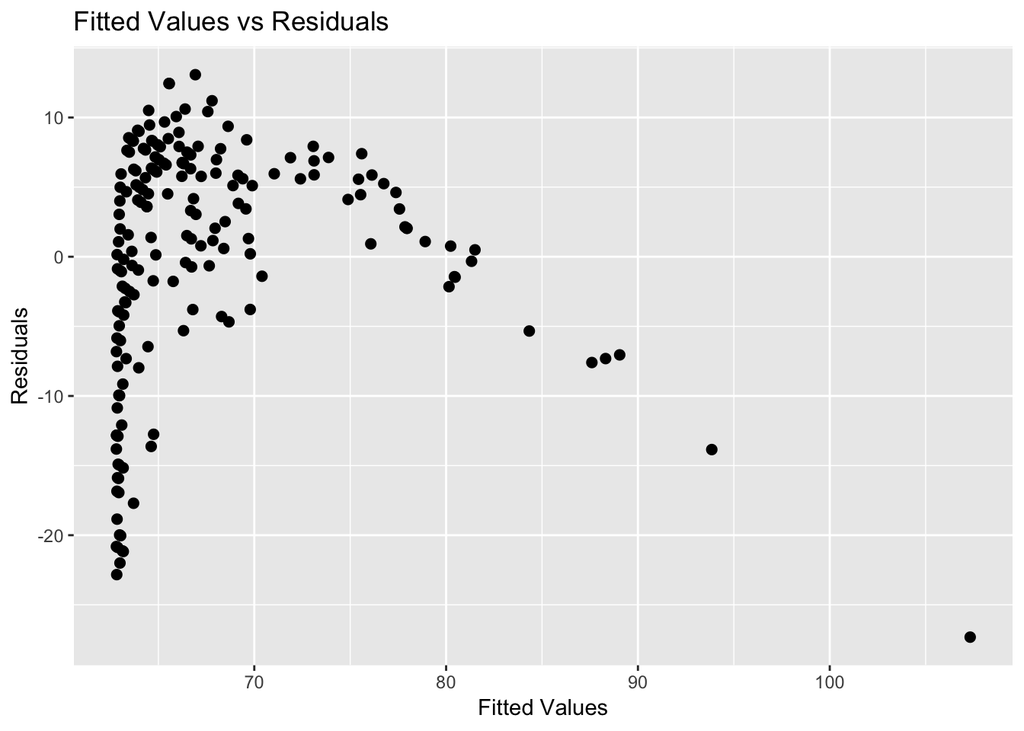

```r
ggplot(lm_4, aes(.fitted, .resid)) +
  geom_point(color = "black", size=2) +
  labs(title = "Fitted Values vs Residuals") +
  labs(x = "Fitted Values") +
  labs(y = "Residuals")
```

F−Statistic is 34.49 and the Standard Error is 8.765. The p−value is nearly 0. The R2 is 0.3574.

The model explains only 35.74% of variability.

In this new model, we notice that the residuals are not normally distributed.

This model is not a good model to describe the relationships between variables TotExp, PropMd and LifeExp.

### Question 5: Forecast LifeExp when PropMD=.03 and TotExp = 14. Does this forecast seem realistic? Why or why not?

```r
propmd = 0.03
totexp = 14

y =lm_4$coefficients[1] +
   lm_4$coefficients[2] * propmd +
   lm_4$coefficients[3] * totexp  +
   lm_4$coefficients[4]*propmd * totexp
print(y)
```

```
## (Intercept)
##     107.696
```

When propmd = 0.03 and totexp = 14, the forecast value of life expectancy is 107.69 years which is unrealistic.